# other-lakes-phenology

Justin Pomeranz

17 August, 2023

## Ice phenology for non-YSL lakes

### Overview

- This script analyzes ice phenology data for lakes other than Yellowstone.
- It runs some simple, prelimanry OLS regressions
- At the bottom, it adds the Yellowstone data to the figures for comparison across lakes.
  - This can be considered a first draft for the “new” figure 2 from the manuscript, comparing ice on, off, and duration dates for all 8 lakes.

#### Figures

I removed legends from figures and increased default size for visualization.

### Libraries

```r
# libraries
library(tidyverse)
library(broom)
```

### Read in data

Note that in this rmarkdown script, the `here::here(...)` code is necessary for markdown to “find” the `other_phenology.txt` file inside of the `scripts/` folder.

```r
non_ysl <- read_csv(here::here("scripts/other_phenology.txt"))
```

#### Note on the data

I copied the raw data from: https://github.com/afilazzola/IcePhenologyDatabase/blob/main/data/PhenologyData.csv#L6

When I tried to download the original csv file, excel was doing weird things with the date columns. This occurred even when I copied/pasted directly into excel, and changed the advanced settings for “text to columns” option.

I found a workaround:  
1. I copied the raw data from the github link above  
2. Pasted the raw values into notepad and saved as a `.txt` file  
3. read in the `.txt` file  
4. All dates correctly imported as `<date>` format.

### Modify the data

Because ice-on dates in the northern hemisphere occur during winter, it is necessary to calculate the julian dates based on the water year, which starts on October 1. To calculate this, I copied the custom `hydro.day()` function from Bella Oleksy’s original analysis. The original function can be found in the `0_functions.R` script.

```r
# custom function to caluclate julian-day of water year
hydro.day = function(x, start.month = 10L) {
  start.yr = year(x) - (month(x) < start.month)
  start.date = make_date(start.yr, start.month, 1L)
  as.integer(x - start.date + 1L)
}
```

#### Make the data for the figures

- Select the columns
- filter out appropriate lakes
  - Get criteria from Scott

```r
fig_dat <- non_ysl %>%
  # select necessary columns
  select(lake, lakecode, start_year, iceOn, iceOff, orig_duration) %>%
  # filter out lakes:
  filter(lakecode == "JK25"| # Lake Haukivesi
           lakecode == "JK02"| # Lake Kallavesi
           lakecode == "GW369"| # Lake Kallsjön
           lakecode == "JK03"| # Näsijärvi
           lakecode == "JK05"| # Päijänne
           lakecode == "JK40"| # Pielinen
           lakecode == "NG1" # Lake Baikal
         )
```

Now, we need to modify the data slightly.

- calculate “hydro day” (Julian day of water year, starting on Oct 1)
- filter years between 1927 to 2022
- Calculate ice duration days
  - Note: Original “phenology” data set did include a column `orig_duration` which has the number of days in it
  - Not all observations (year-lake combinations) had this calculated
  - `ice_days` is a new column with the number of days the ice was there
  - `dur_eq` is a logical column to show whether or not new calculation matches original

```r
fig_dat <- fig_dat %>%
  # caluclate on and off julian dates for water year
  mutate(j_on_wy = hydro.day(iceOn),
         j_off_wy = hydro.day(iceOff)) %>%
  # filter out data only from 1927 to 2022
  filter(start_year >= 1927, start_year <=2022) %>%
  mutate(ice_days = j_off_wy - j_on_wy,
         dur_eq = ice_days == orig_duration)
head(fig_dat)
```

```
## # A tibble: 6 x 10
##   lake  lakecode start_year iceOn      iceOff     orig_duration j_on_wy j_off_wy
##   <chr> <chr>         <dbl> <date>     <date>             <dbl>   <int>    <int>
## 1 kall~ GW369          1927 1927-12-16 1928-05-26            NA      77      239
## 2 kall~ GW369          1928 1928-12-16 1929-05-20            NA      77      232
## 3 kall~ GW369          1929 1930-02-20 1930-05-03            NA     143      215
## 4 kall~ GW369          1930 1931-01-06 1931-05-16            NA      98      228
## 5 kall~ GW369          1931 1931-12-29 1932-05-22            NA      90      235
## 6 kall~ GW369          1932 1933-01-12 1933-05-27            NA     104      239
## # i 2 more variables: ice_days <int>, dur_eq <lgl>
```

Do any of the calculations result in different number of ice duration days?

```r
fig_dat %>%
  select(ice_days, orig_duration, dur_eq) %>%
  filter(dur_eq == FALSE)
```

```
## # A tibble: 0 x 3
## # i 3 variables: ice_days <int>, orig_duration <dbl>, dur_eq <lgl>
```

### Figure 2a: ice-on date

Plot the data to match panel a from figure 2.

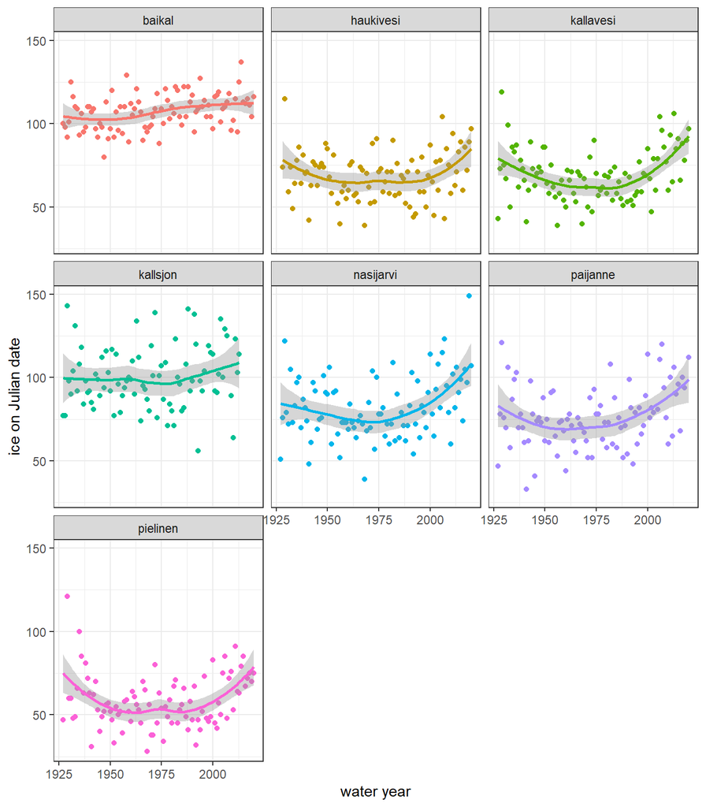

```r
# figure a ice off j_data
fig_dat %>%
  ggplot(aes(x = start_year,
             y = j_on_wy,
             color = lake)) +
  geom_point() +
  stat_smooth() +
  facet_wrap(~lake) +
  theme_bw() +
  labs(x = "water year",
       y = "ice on Julian date") +
  theme(legend.position = "none")
```

Appears that ice on day is flat to possibly occurring later in the year. Although the “U” shape of many of them is interesting. Indicates that ice-on used to be later in the year, and then got earlier in the mid-century, only to get later again in the more recent decades.

#### “Global” ice-on relationship

This is probably not a valid analysis, but including because I’m curious

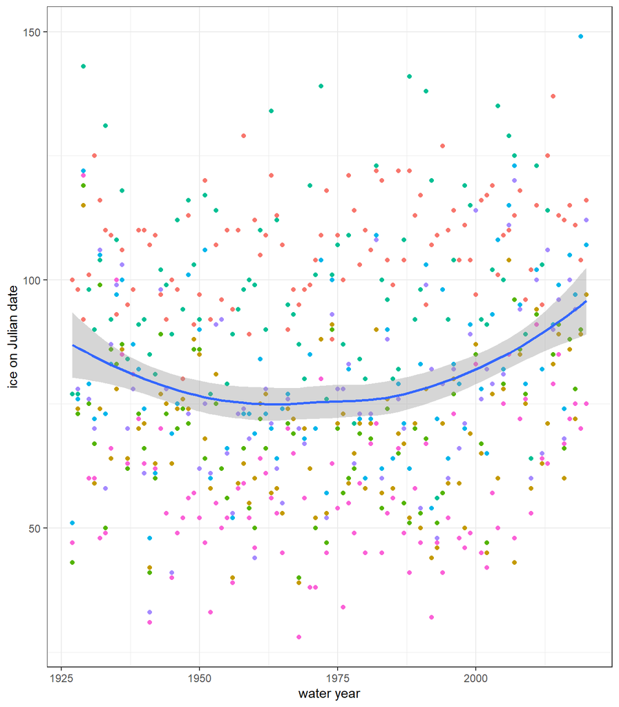

```r
fig_dat %>%
  ggplot(aes(x = start_year,
             y = j_on_wy,
             color = lake)) +
  geom_point() +
  stat_smooth(inherit.aes = FALSE,
              aes(x = start_year,
                  y = j_on_wy))+
  theme_bw() +
  labs(x = "water year",
       y = "ice on Julian date") +
  theme(legend.position = "none")
```

Maybe some variation across tie, but the “U” shape is not encouraging.

### Figure 2b: ice-off

Plot the data to match panel b from figure 2: ice off dates

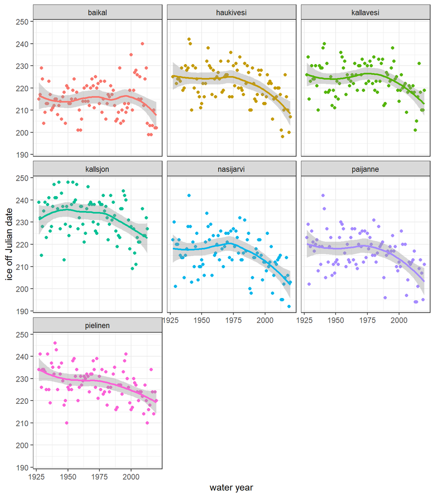

```r
# figure a ice off j_data
fig_dat %>%
  ggplot(aes(x = start_year,
             y = j_off_wy,
             color = lake)) +
  geom_point() +
  stat_smooth() +
  facet_wrap(~lake) +
  theme_bw() +
  labs(x = "water year",
       y = "ice off Julian date") +
  theme(legend.position = "none")
```

Possibly a bit more of a consistent result for early ice-off dates.

#### “Global” ice-off

Again, probably not a valid analysis, but including for visualization.

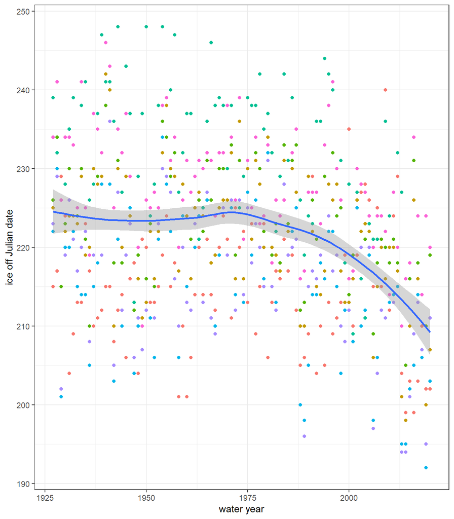

```r
fig_dat %>%
  ggplot(aes(x = start_year,
             y = j_off_wy,
             color = lake)) +
  geom_point() +
  stat_smooth(inherit.aes = FALSE,
              aes(x = start_year,
                  y = j_off_wy))+
  theme_bw() +
  labs(x = "water year",
       y = "ice off Julian date") +
  theme(legend.position = "none")
```

This “global” relationship is more stark. Quite the change (earlier ice-off) in the last ~50 years or so!

### Figure 2c: duration

Plot the data to match panel c from figure 2: ice duration days

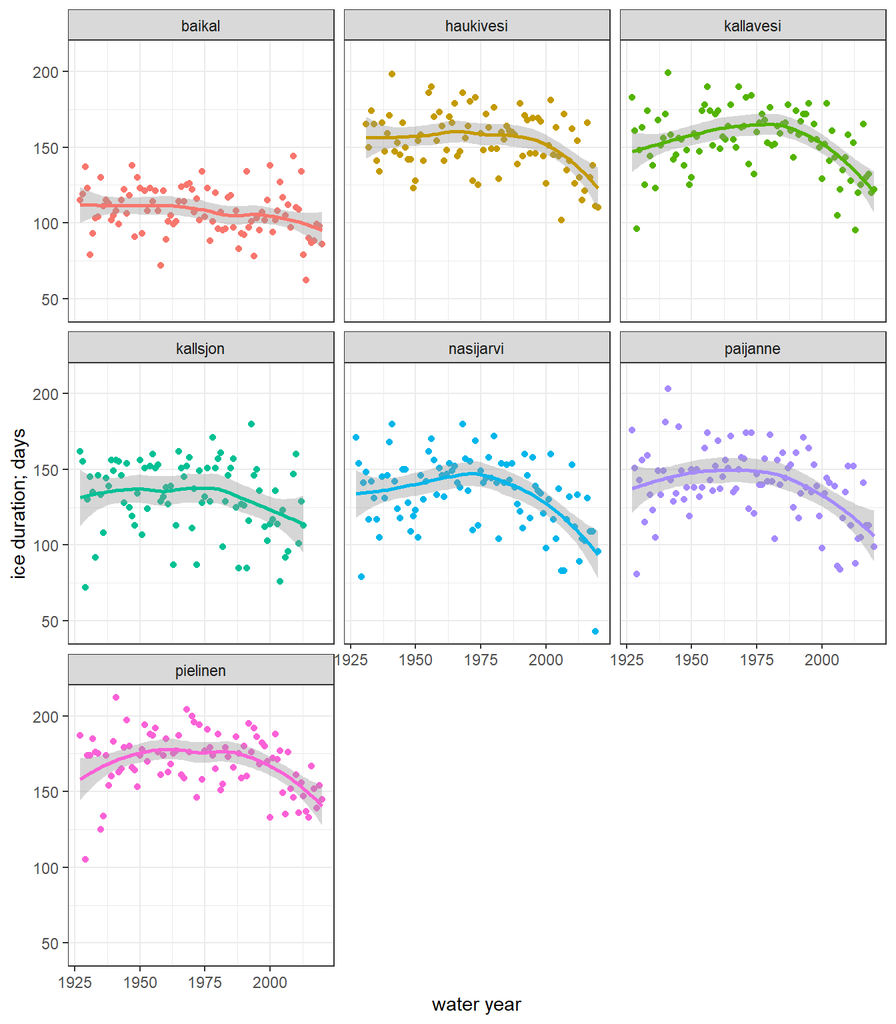

```r
# figure a ice off j_data
fig_dat %>%
  ggplot(aes(x = start_year,
             y = ice_days,
             color = lake)) +
  geom_point() +
  stat_smooth() +
  facet_wrap(~lake) +
  theme_bw() +
  labs(x = "water year",
       y = "ice duration; days") +
  theme(legend.position = "none")
```

Total ice duration appears to be flat or slightly decreasing.

#### Global duration

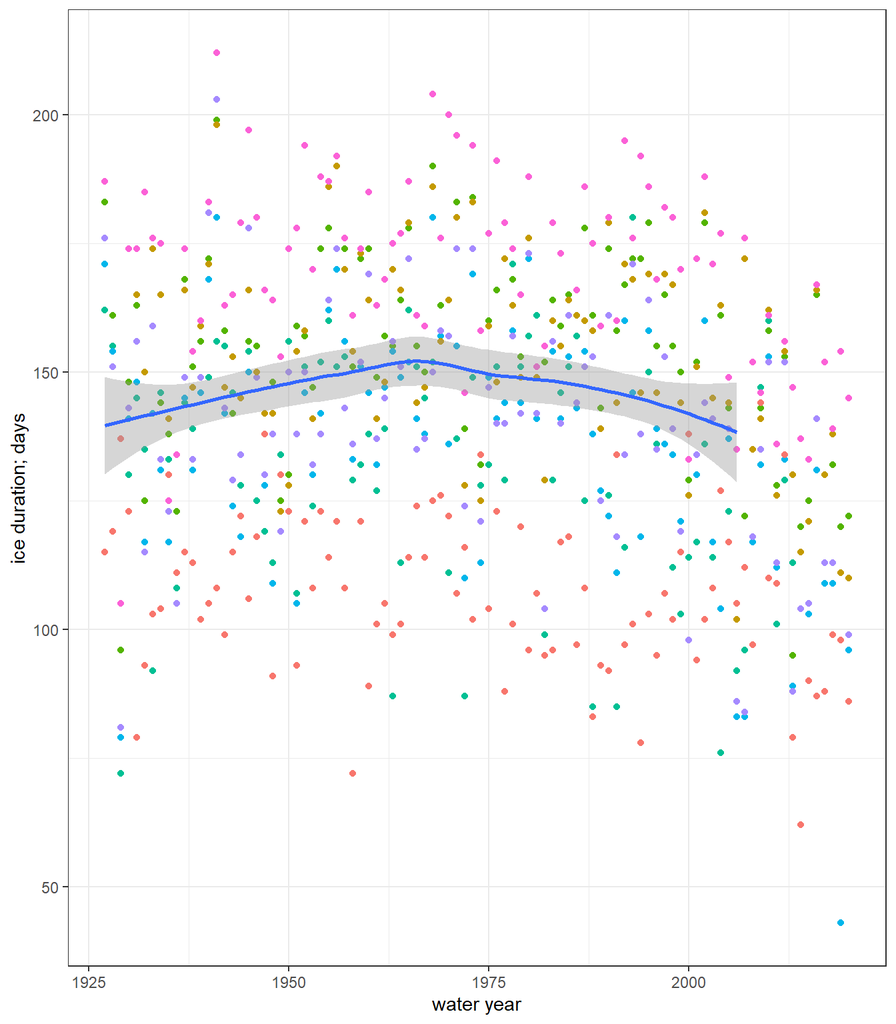

```r
fig_dat %>%
  ggplot(aes(x = start_year,
             y = ice_days,
             color = lake)) +
  geom_point() +
  stat_smooth(inherit.aes = FALSE,
              aes(x = start_year,
                  y = orig_duration))+
  theme_bw() +
  labs(x = "water year",
       y = "ice duration; days") +
  theme(legend.position = "none")
```

Appears to be declining. Not sure why the geom_smooth line stops early. I thought it was due to a lack of data at some sites (lake == storuman), but when I filtered it out and plotted again the line still stopped short.

- Missing observations in later years?

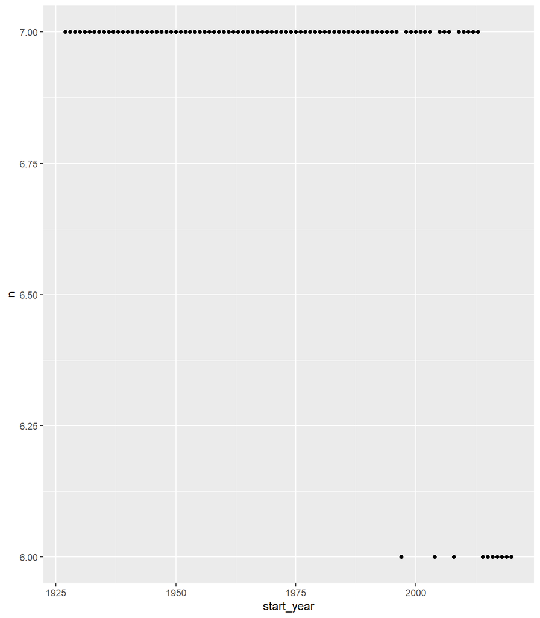

```r
# missing data in later years
fig_dat %>%
  group_by(start_year) %>%
  count() %>%
  ggplot(aes(x = start_year,
             y = n)) +
  geom_point()
```

Appears that there is a lack of data in some of the more recent years. As I said before, the “global”-level analysis is probably confounded anyways. Fitting individual regressesions below to explore relationships within each lake.

## Basic linear models, just for “fun”

The following code:  
* fits a basic linear model looking at response variable (ice on, off, duration) by year (centered).

- Models are fit independently for each lake.
- Results are filtered to only show significant results for the $\beta_1$ (i.e., slope) coefficient.

Not sure if we want to actually analyze this data. I don’t think this is the *best* analysis for this, but just putting on here as an example.

On second thoughts, if we want to do something like this, a GAM or similar is probably the best. Based on the plots above, it does seem that there might be a drop off or threshold response, and simple Ordinary Least Squares (linear) relationships are probably not the best for that.

I haven’t fit GAMs in a while so would need to look into that more. But could be done if we think it’s worth exploring.

#### Ice on

**NOTE** that `library(broom)` is required.

```r
# ice on ~ time
fig_dat %>%
  group_by(lake) %>%
  # center the year based on the range of data for each lake
  # not sure if this is totally correct, might need to center it based on years in the "global" data set
  # FWIW I tried both and same number of significant lakes
  mutate(start_y_c = start_year - mean(start_year)) %>%
  nest() %>%
  mutate(model = map(data, ~lm(j_on_wy~start_y_c, data = .)%>% tidy())) %>%
  unnest(model) %>%
  filter(term == "start_y_c",
         p.value < 0.05) %>%
  mutate(beta1_positive = case_when(estimate > 0  ~ TRUE,
                                    estimate < 0  ~FALSE)) %>%
  select(lake, estimate, p.value, beta1_positive)
```

```
## # A tibble: 3 x 4
## # Groups:   lake [3]
##   lake      estimate  p.value beta1_positive
##   <chr>        <dbl>    <dbl> <lgl>
## 1 nasijarvi    0.171 0.0144   TRUE
## 2 paijanne     0.158 0.0248   TRUE
## 3 baikal       0.129 0.000899 TRUE
```

3 lakes (out of 7) have shown an increase (later) ice on dates

#### Ice off

```r
# ice off ~ time
fig_dat %>%
  group_by(lake) %>%
  # center the year based on the range of data for each lake
  # not sure if this is totally correct, might need to center it based on years in the "global" data set
  # FWIW I tried both and same number of significant lakes
  mutate(start_y_c = start_year - mean(start_year)) %>%
  nest() %>%
  mutate(model = map(data, ~lm(j_off_wy~start_y_c, data = .)%>% tidy())) %>%
  unnest(model) %>%
  filter(term == "start_y_c",
         p.value < 0.05) %>%
  mutate(beta1_positive = case_when(estimate > 0  ~ TRUE,
                                    estimate < 0  ~FALSE)) %>%
  select(lake, estimate, p.value, beta1_positive)
```

```
## # A tibble: 6 x 4
## # Groups:   lake [6]
##   lake      estimate    p.value beta1_positive
##   <chr>        <dbl>      <dbl> <lgl>
## 1 kallsjon   -0.115  0.00272    FALSE
## 2 kallavesi  -0.0839 0.00325    FALSE
## 3 nasijarvi  -0.131  0.000158   FALSE
## 4 paijanne   -0.129  0.000121   FALSE
## 5 haukivesi  -0.140  0.00000894 FALSE
## 6 pielinen   -0.122  0.00000841 FALSE
```

6 lakes (out of 7) show a decrease in ice off dates (earlier).

#### Ice duration

```r
# ice duration ~ time
fig_dat %>%
  group_by(lake) %>%
  # center the year based on the range of data for each lake
  # not sure if this is totally correct, might need to center it based on years in the "global" data set
  # FWIW I tried both and same number of significant lakes
  mutate(start_y_c = start_year - mean(start_year)) %>%
  nest() %>%
  mutate(model = map(data, ~lm(ice_days~start_y_c, data = .)%>% tidy())) %>%
  unnest(model) %>%
  filter(term == "start_y_c",
         p.value < 0.05) %>%
  mutate(beta1_positive = case_when(estimate > 0  ~ TRUE,
                                    estimate < 0  ~FALSE)) %>%
  select(lake, estimate, p.value, beta1_positive)
```

```
## # A tibble: 6 x 4
## # Groups:   lake [6]
##   lake      estimate  p.value beta1_positive
##   <chr>        <dbl>    <dbl> <lgl>
## 1 kallavesi   -0.165 0.0336   FALSE
## 2 nasijarvi   -0.303 0.000746 FALSE
## 3 paijanne    -0.276 0.00180  FALSE
## 4 haukivesi   -0.224 0.00393  FALSE
## 5 pielinen    -0.169 0.0216   FALSE
## 6 baikal      -0.141 0.0178   FALSE
```

6 lakes (out of 7) show a decrease in duration of ice.

## Figures with all lakes

```r
ysl_ice <- read.csv(here::here("scripts/YSLoff.csv")) %>%
  select(Year, IceOnDate, IceOffDate,) %>%
  mutate(lake = "yellowstone")
```

Modify data with `hydro.day()` function

- first need to combine ice on / off day with year
- format as date
- calculate “hydro day”
- calculate ice duration days
- rename and select columns to match with fig_data

```r
ysl_ice <- ysl_ice %>%
  unite(IceOnDate, c(IceOnDate, Year), sep = "-", remove = FALSE) %>%
  unite(IceOffDate, c(IceOffDate, Year), sep = "-", remove = FALSE) %>%
  mutate(on_date = dmy(IceOnDate),
         off_date = dmy(IceOffDate)) %>%
  mutate(j_on_wy = hydro.day(on_date),
         j_off_wy = hydro.day(off_date),
         ice_days = j_off_wy - j_on_wy) %>%
  rename(start_year = Year) %>%
  select(lake, start_year, j_on_wy, j_off_wy, ice_days)
```

## Double check

**Note**: Make sure this is right. Looking at the YSL data, there is just one “Year” column, but sometimes the ice forms at the end of the year (i.e., Dec) or the beginning of the year (i.e. Jan). Is combining the ice on/off date with that year correct? May be “ading” a year’s worth of ice duration.

### Back to combining data…

Bind rows for the ysl and non-ysl data

```r
full_fig <- bind_rows(fig_dat, ysl_ice)
full_fig
```

```
## # A tibble: 744 x 10
##    lake     lakecode start_year iceOn      iceOff     orig_duration j_on_wy
##    <chr>    <chr>         <dbl> <date>     <date>             <dbl>   <int>
##  1 kallsjon GW369          1927 1927-12-16 1928-05-26            NA      77
##  2 kallsjon GW369          1928 1928-12-16 1929-05-20            NA      77
##  3 kallsjon GW369          1929 1930-02-20 1930-05-03            NA     143
##  4 kallsjon GW369          1930 1931-01-06 1931-05-16            NA      98
##  5 kallsjon GW369          1931 1931-12-29 1932-05-22            NA      90
##  6 kallsjon GW369          1932 1933-01-12 1933-05-27            NA     104
##  7 kallsjon GW369          1933 1934-02-08 1934-05-11            NA     131
##  8 kallsjon GW369          1934 1934-12-31 1935-05-26            NA      92
##  9 kallsjon GW369          1935 1936-01-16 1936-05-28            NA     108
## 10 kallsjon GW369          1936 1937-01-26 1937-05-14            NA     118
## # i 734 more rows
## # i 3 more variables: j_off_wy <int>, ice_days <int>, dur_eq <lgl>
```

Change data shape to plot a single, multi-panel figure.  
* also added “free y” scale to try and better illustrate the trends.

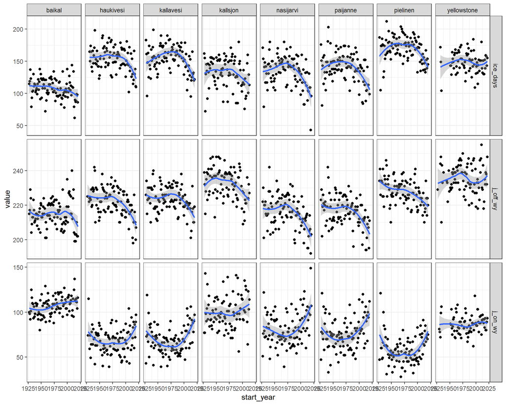

```r
full_fig %>%
  select(lake, start_year, ice_days, j_on_wy, j_off_wy) %>%
  pivot_longer(ice_days:j_off_wy) %>%
  ggplot(aes(x = start_year,
             y = value)) +
  geom_point() +
  theme_bw() +
  facet_grid(name ~ lake, scales = "free_y") +
  geom_smooth()
```

**Note**: It’s difficult to get the scaling right on this large, multi-panel plot. Depending on your browser/window it may look funny. The main take-home message is that Yellowstone is ~ flat across all three responses, while there is some variation across the other lakes.

## Linear models including Yellowstone

For reference.

- might not need this type of analysis
- linear models are almost certainly not the best wat to do this

```r
# ice on ~ time
full_fig %>%
  group_by(lake) %>%
  # center the year based on the range of data for each lake
  # not sure if this is totally correct, might need to center it based on years in the "global" data set
  # FWIW I tried both and same number of significant lakes
  mutate(start_y_c = start_year - mean(start_year)) %>%
  nest() %>%
  mutate(model = map(data, ~lm(j_on_wy~start_y_c, data = .)%>% tidy())) %>%
  unnest(model) %>%
  filter(term == "start_y_c",
         p.value < 0.05) %>%
  mutate(beta1_positive = case_when(estimate > 0  ~ TRUE,
                                    estimate < 0  ~FALSE)) %>%
  select(lake, estimate, p.value, beta1_positive)
```

```
## # A tibble: 3 x 4
## # Groups:   lake [3]
##   lake      estimate  p.value beta1_positive
##   <chr>        <dbl>    <dbl> <lgl>
## 1 nasijarvi    0.171 0.0144   TRUE
## 2 paijanne     0.158 0.0248   TRUE
## 3 baikal       0.129 0.000899 TRUE
```

#### Ice off

```r
# ice off ~ time
full_fig %>%
  group_by(lake) %>%
  # center the year based on the range of data for each lake
  # not sure if this is totally correct, might need to center it based on years in the "global" data set
  # FWIW I tried both and same number of significant lakes
  mutate(start_y_c = start_year - mean(start_year)) %>%
  nest() %>%
  mutate(model = map(data, ~lm(j_off_wy~start_y_c, data = .)%>% tidy())) %>%
  unnest(model) %>%
  filter(term == "start_y_c",
         p.value < 0.05) %>%
  mutate(beta1_positive = case_when(estimate > 0  ~ TRUE,
                                    estimate < 0  ~FALSE)) %>%
  select(lake, estimate, p.value, beta1_positive)
```

```
## # A tibble: 6 x 4
## # Groups:   lake [6]
##   lake      estimate    p.value beta1_positive
##   <chr>        <dbl>      <dbl> <lgl>
## 1 kallsjon   -0.115  0.00272    FALSE
## 2 kallavesi  -0.0839 0.00325    FALSE
## 3 nasijarvi  -0.131  0.000158   FALSE
## 4 paijanne   -0.129  0.000121   FALSE
## 5 haukivesi  -0.140  0.00000894 FALSE
## 6 pielinen   -0.122  0.00000841 FALSE
```

#### Ice duration

```r
# ice duration ~ time
full_fig %>%
  group_by(lake) %>%
  # center the year based on the range of data for each lake
  # not sure if this is totally correct, might need to center it based on years in the "global" data set
  # FWIW I tried both and same number of significant lakes
  mutate(start_y_c = start_year - mean(start_year)) %>%
  nest() %>%
  mutate(model = map(data, ~lm(ice_days~start_y_c, data = .)%>% tidy())) %>%
  unnest(model) %>%
  filter(term == "start_y_c",
         p.value < 0.05) %>%
  mutate(beta1_positive = case_when(estimate > 0  ~ TRUE,
                                    estimate < 0  ~FALSE)) %>%
  select(lake, estimate, p.value, beta1_positive)
```

```
## # A tibble: 6 x 4
## # Groups:   lake [6]
##   lake      estimate  p.value beta1_positive
##   <chr>        <dbl>    <dbl> <lgl>
## 1 kallavesi   -0.165 0.0336   FALSE
## 2 nasijarvi   -0.303 0.000746 FALSE
## 3 paijanne    -0.276 0.00180  FALSE
## 4 haukivesi   -0.224 0.00393  FALSE
## 5 pielinen    -0.169 0.0216   FALSE
## 6 baikal      -0.141 0.0178   FALSE
```

#### For what it’s worth….

Yellowstone lake was not included in any of the significant OLS regressions. On the surface, this seems to agree with main points of the MS, and at least *some* of the comparable lakes did have significant changes.